# Lecture6_ggplot

Kelly

Ah, the swirling ocean of code that shows up in the wake of a popular, free, and open-source project like **R**. So many people write so many packages for so many things. There are packages for [analyzing baseball data, for example](https://github.com/BillPetti/baseballr), or [tennis data, for that matter](https://github.com/skoval/deuce). [Calculating carbonate chemistry](https://cran.r-project.org/web/packages/seacarb/index.html), [waveform analysis](https://cran.r-project.org/web/packages/seewave/index.html), [organizing musical chord charts](https://www.analyticsvidhya.com/blog/2018/08/chorrrds-r-package-analyzing-working-music-data/), [exploring census data](https://cran.r-project.org/web/packages/census/index.html), and surely a thousand other things.

But making beautiful plots is something that **R** does well, and Hadley Wickham’s package **ggplot2** is probably the best out there for doing it. You’re already aware that this package exists, but today we’re going to take it for a spin.

There’s a whole theory of graphics underlying **ggplot2**, and you can learn a lot more about it [here](https://ggplot2.tidyverse.org/). But let’s start with the helpfile for the package.

```r
library(ggplot2)

?ggplot
```

[Note: for ease of use, I’ll be using a single data set in this class. It’s built-in, and is called `mpg`, which stands for Miles Per Gallon, and is about automobile efficiency.]

```r
head(mpg)
```

```
## # A tibble: 6 x 11
##   manufacturer model displ  year   cyl trans drv     cty
##   <chr>        <chr> <dbl> <int> <int> <chr> <chr> <int>
## 1 audi         a4      1.8  1999     4 auto… f        18
## 2 audi         a4      1.8  1999     4 manu… f        21
## 3 audi         a4      2    2008     4 manu… f        20
## 4 audi         a4      2    2008     4 auto… f        21
## 5 audi         a4      2.8  1999     6 auto… f        16
## 6 audi         a4      2.8  1999     6 manu… f        18
## # … with 3 more variables: hwy <int>, fl <chr>, class <chr>
```

The most confusing thing about **ggplot2** is that it doesn’t use exactly the same syntax as the rest of **R**, for reasons that we won’t go into (and that I don’t really understand).

Essentially, though, you use it to first create a canvas `ggplot()`, and then you add elements to that canvas, piecemeal. You use the `+` symbol to tell the package that you are adding another element to the plot.

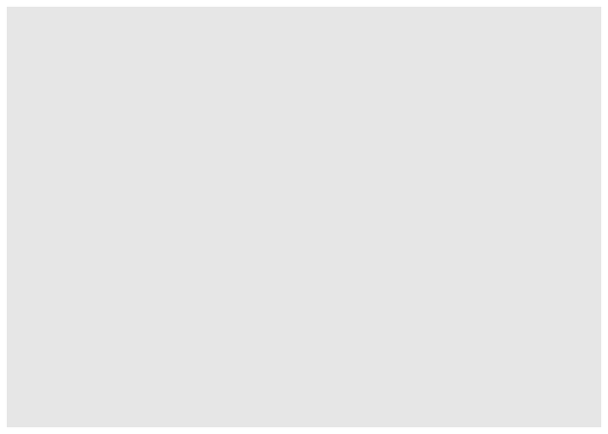

```r
ggplot(mpg)  #just gives you the canvas
```

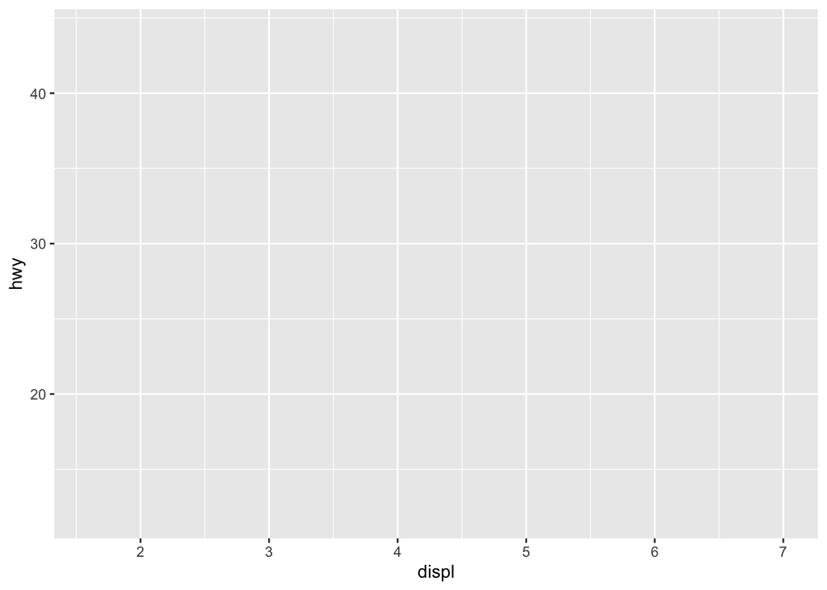

```r
ggplot(data = mpg,   #here, we're using a built-in dataset featuring info on different cars
  aes(x = displ, y = hwy , color = class) #the "aes" argument adds aesthetic properties to your plot.
  #You always need this to tell ggplot what you'd like to be plotting.
  )
```

OK – so now we’ve told the package what we would like to plot (that is, what dataframe the data are coming from (mpg), the *x* and *y* variables, and that we want to vary the plot by color according to the class of the car being described.) But why is nothing plotted?

Because **ggplot2** is very needy. You actually need to tell it you want to plot POINTS, in this case. You do this with another layer of the graphic, called a *geom* (which is just basically the kind of plot you want… scatterplot, barplot, etc)

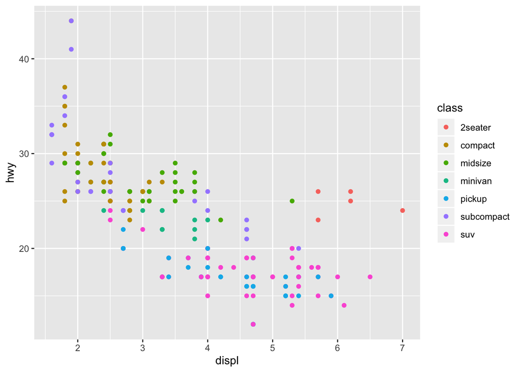

```r
ggplot(data = mpg,
  aes(x = displ, y = hwy , color = class)) +  #same code as above, but now with...
  geom_point()  #to tell ggplot that you want to plot points
```

Now, isn’t that nice? And in fact, we can make lots of different plots using similar code.

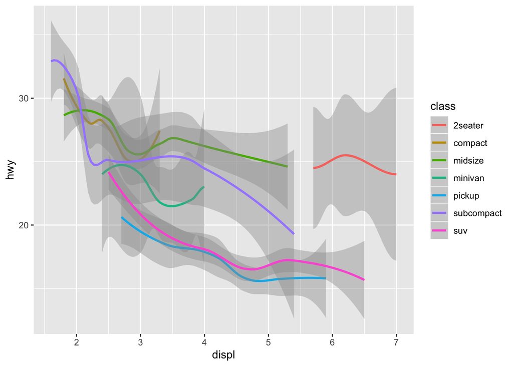

```r
baseinfo <- ggplot(data = mpg,
  aes(x = displ, y = hwy , color = class)
  )  #I'll save all of this as an object called "baseinfo", for ease of typing...

baseinfo + geom_smooth()  #for example, to plot smoothed lines and some semblance of confidence intervals showing the trends of each of the classes of cars
```

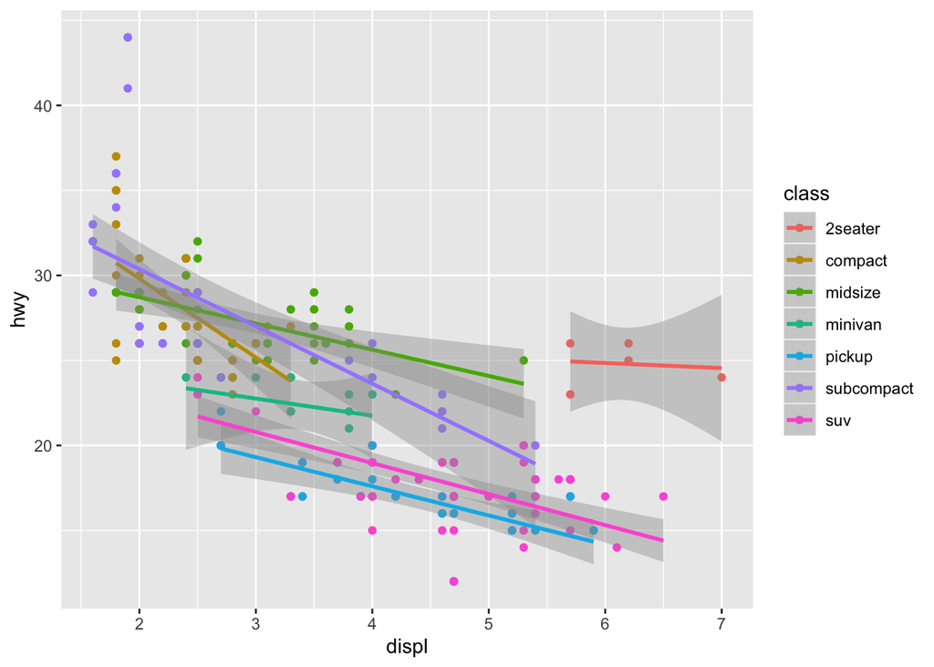

```r
baseinfo + geom_point() + geom_smooth(method = "lm") #or, for example, to plot both the points and a linear model for each grouping
```

We add things like titles and text and axis labels to the plot in the same way.

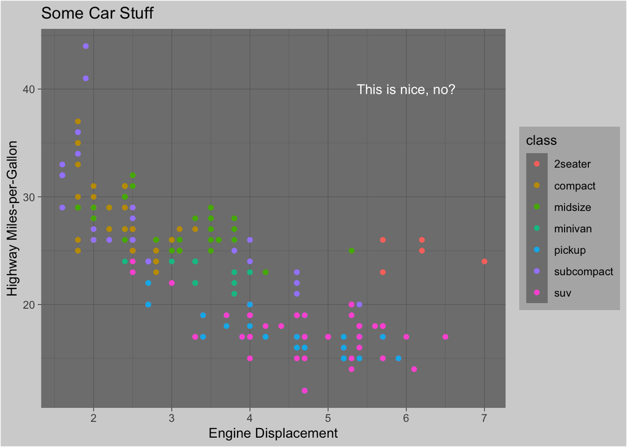

```r
baseinfo + geom_point() +
  ggtitle("Some Car Stuff") + labs(x = "Engine Displacement", y = "Highway Miles-per-Gallon") +
  annotate("text", x = 6, y = 40, label ="This is nice, no?", color = "white") +
  theme_dark() + #one of several pre-set themes;
  #you can change everything about the plot, such as the background color, which I'm doing here
  theme(plot.background = element_rect(fill = "lightgrey"),
        legend.background = element_rect(fill = "grey70"))
```

So you can see the appeal. Once you get the hang of it, you can make all kinds of very nice plots… and more than plots, these are really *analyses*. For example, linear models of the subsets of different cars, as shown above.

Some further examples:

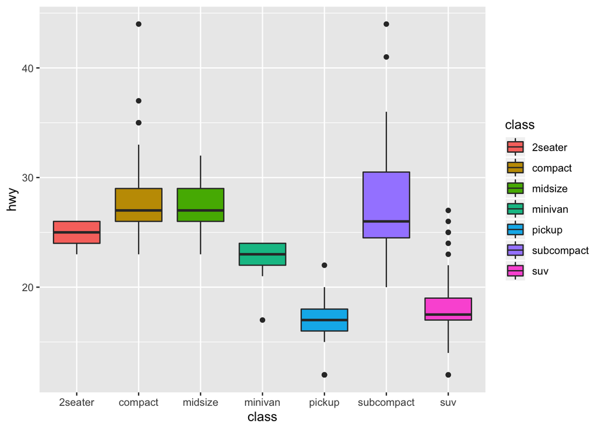

```r
ggplot(mpg, aes(class, hwy, fill=class)) +
  geom_boxplot()  #Boxplot
```

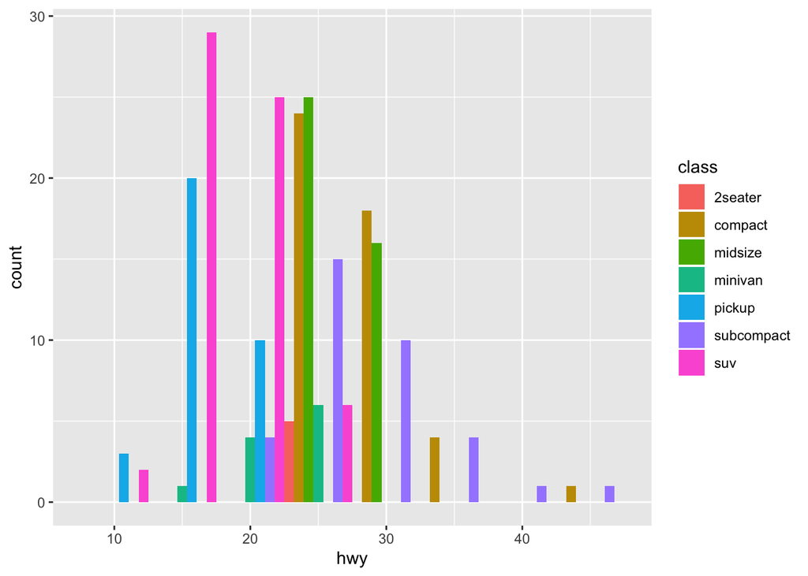

```r
ggplot(mpg, aes(hwy, fill=class)) +
  geom_histogram(binwidth = 5, position = "dodge")  #Side-by-side histogram
```

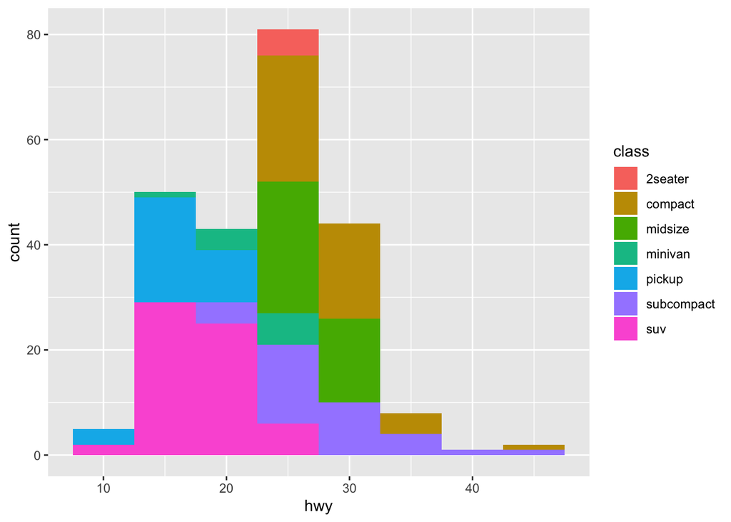

```r
ggplot(mpg, aes(hwy, fill=class)) +
  geom_histogram(binwidth = 5)  #stacked histogram
```

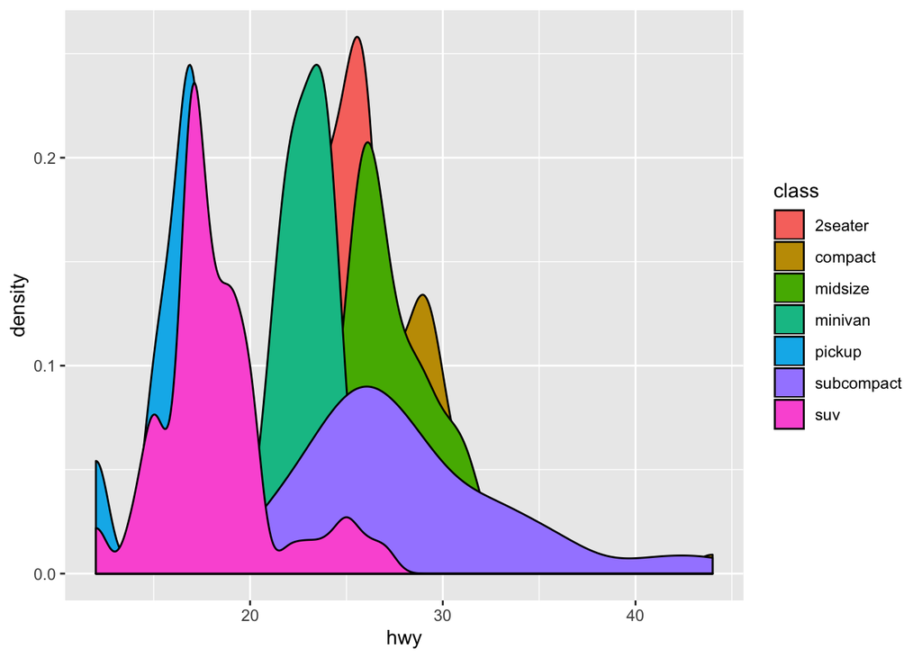

```r
ggplot(mpg, aes(hwy, fill=class)) +
  geom_density()  #density plot
```

## Facets

And perhaps the most useful thing about **ggplot**… you can create subplots for different subsets of your data. Which is very often something you want to do. Those subplots are, for some reason, called *facets*.

Note how convenient this is: you don’t have to split your data into subsets, because **ggplot** does it for you.

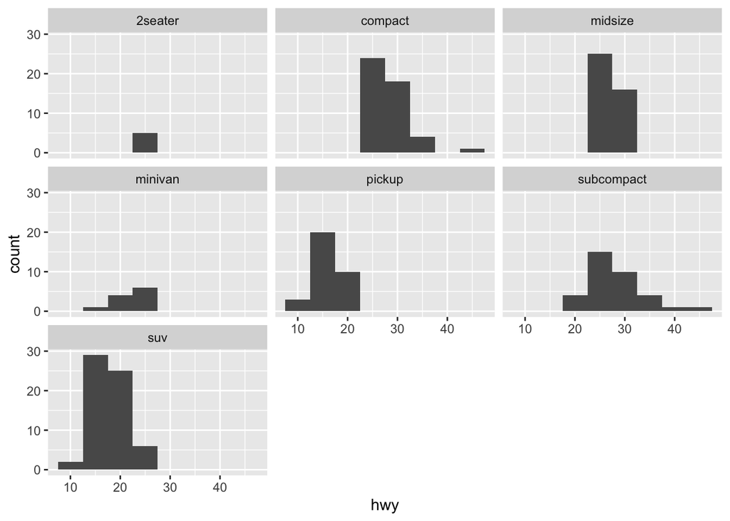

```r
ggplot(mpg, aes(hwy)) +
  geom_histogram(binwidth = 5) +
  facet_wrap(~class)
```

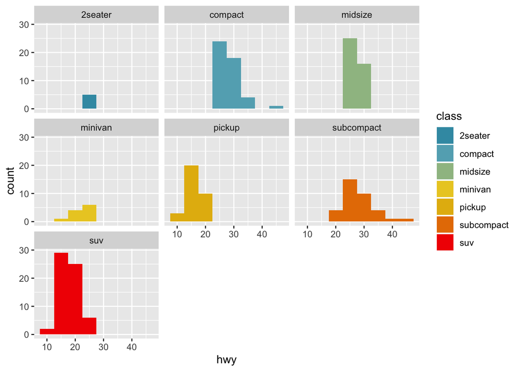

```r
#or you can make the same plot some fun colors...

library(wesanderson) #load library wesanderson
ggplot(mpg, aes(hwy, fill = class)) +
  geom_histogram(binwidth = 5) +
  facet_wrap(~class) +
  scale_fill_manual(values=wes_palette(n=7, name="Zissou1", type = "continuous"))
```

```r
#or
library(viridis) #load library viridis
```

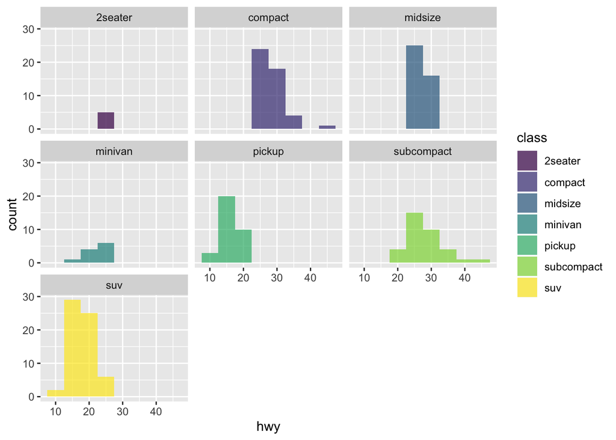

```r
ggplot(mpg, aes(hwy, fill = class)) +
  geom_histogram(binwidth = 5) +
  facet_wrap(~class) +
  scale_fill_manual(values=viridis(n=7, alpha = .7))
```

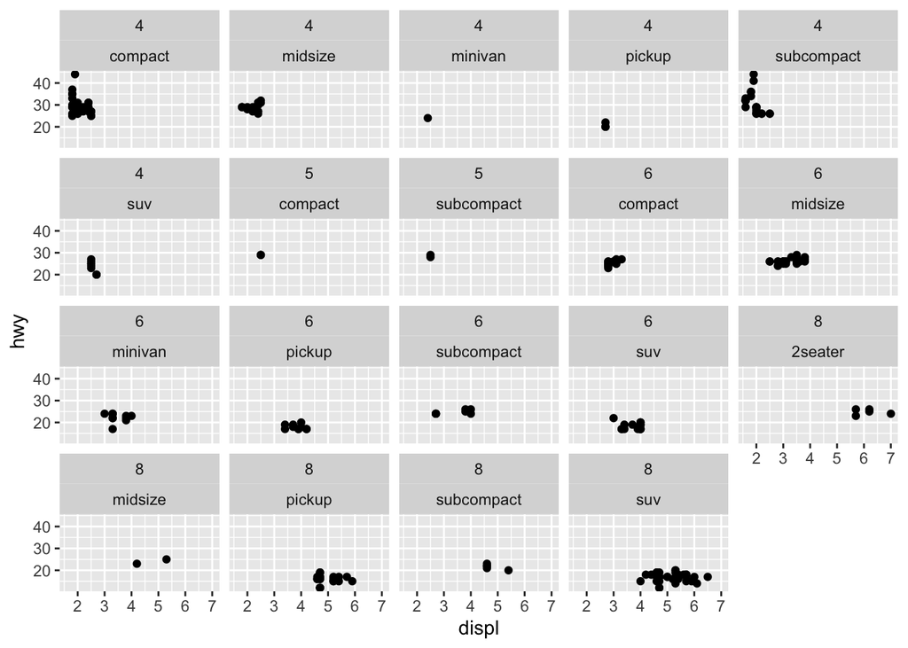

```r
#see this link for more ideas and examples:  http://www.sthda.com/english/wiki/ggplot2-colors-how-to-change-colors-automatically-and-manually

#and you can even facet_wrap by multiple variables:

ggplot(mpg, aes(displ, hwy)) +
  geom_point() +
  facet_wrap(~ cyl + class)
```

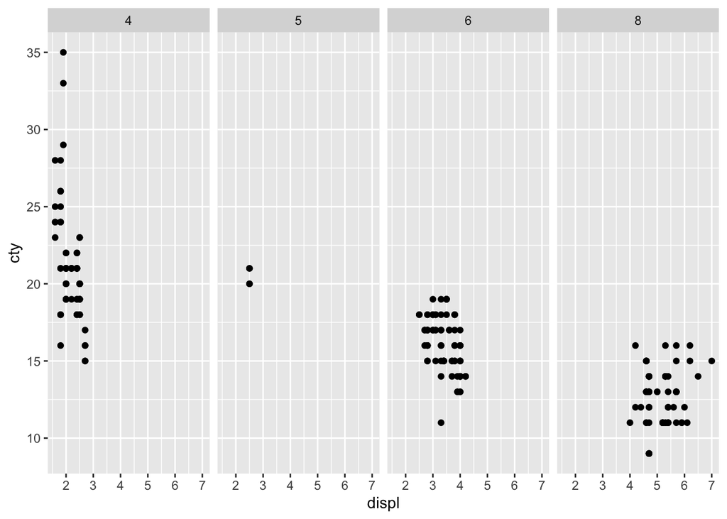

```r
#facet_grid is a similar idea, but is far better-organized
ggplot(mpg, aes(displ, cty)) + geom_point() +
  facet_grid(. ~ cyl)
```

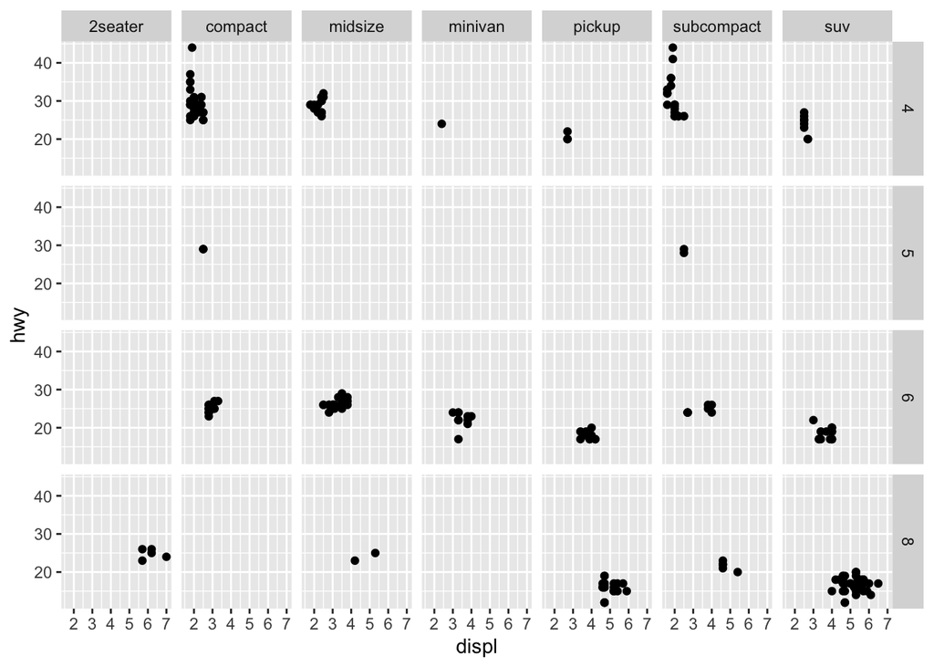

```r
# and works even better when you have crossed factors:
ggplot(mpg, aes(displ, hwy)) +
  geom_point() +
  facet_grid ( cyl ~ class)
```

## Note, too:

Secretly, this is doing a lot of the same work as you were doing with loops and apply(), right? It’s breaking up data into groups, and telling you information about each group. Which is an invaluable analytical tool.

# In-class mini-task

Working in groups at your table, create a colorful grid of scatter plots – each with best-fit lines – from the dataset `mpg`. Tell us something about gas mileage and how it has changed between 1999 and 2008. See `?mpg` for variables. You could also add variables, such as continent/country of origin, and that might be interestin g. For example:

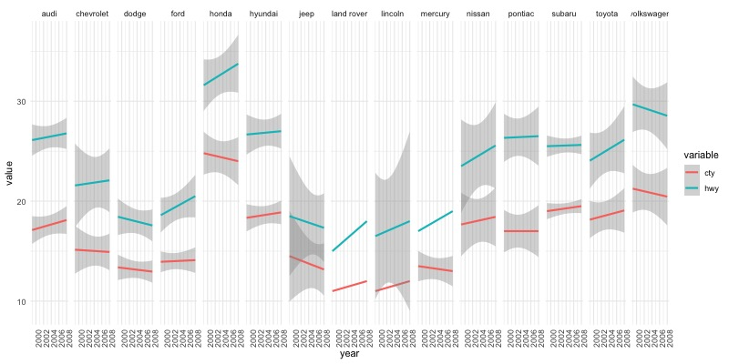